# **Uma Breve Introdução ao R**

Mauro Campos. Departamento de Estatística, UFES. [(Minha página)](http://www.maurocampos.com/)

19 de julho de 2016

R é um software livre que proporciona um ambiente para análise de dados. Este artigo proporciona uma breve introdução ao R para alunos que estão matriculados em disciplinas como: **Estatística Básica** ou **Introdução à Probabilidade e Estatística**. Conhecimentos básicos de R podem auxiliar bastante o estudo de tais disciplinas. Se entender que leitura deste artigo foi útil para os seus interesses, bookmark esta página para consulta futura.

# 1 Instalação do R

R é desenvolvido para diversas plataformas: Linux, Windows e Mac-OS X. Para download R para Windows, basta seguir os seguintes passos:

1. Visite a página web do [Projeto R](https://www.r-project.org/).
2. Escolha um CRAN mirror de sua preferência.
3. Download o instalador adequado para a plataforma Windows.
4. Quando o processo estiver concluído, 2-cliques no instalador e siga as instruções.

Procedimentos para instalação do R para Mac-OS X e Linux também podem ser obtidos na página do Projeto R.

Conheça também o [RStudio](https://www.rstudio.com/) que é um IDE (Integrated Development Environment) para R. O arquivo HTML desta página (*intror.html*) é um exemplo de um projeto desenvolvido no RStudio usando Markdown (Pandoc) e R.

Daqui pra frente, estou assumindo que o R está instalado no seu computador.

# 2 Operadores

## 2.1 Aritméticos

```
+ : adição (addition)
- : subtração (subtraction)
* : multiplicação (multiplication)
/ : divisão (division)
^ : exponenciação (exponentiation)

# Quando desejar comentar uma parte do seu script
# Dica: Ctrl-L limpa o Console
```

```r
2+3
```

```
## [1] 5
```

```r
2-3
```

```
## [1] -1
```

```r
2*3
```

```
## [1] 6
```

```r
2/3
```

```
## [1] 0.6666667
```

```r
2^(3)
```

```
## [1] 8
```

```r
25%/%3 # divisão inteira de 25 por 3
```

```
## [1] 8
```

```r
25%%3 # retorna o resto de 25/3 (25 mod 3)
```

```
## [1] 1
```

```r
1
```

```
## [1] 1
```

## 2.2 De atribuição

```r
pi
```

```
## [1] 3.141593
```

```r
x <- sqrt(2*pi) # Armazena em x o valor raiz de pi
x
```

```
## [1] 2.506628
```

```r
x = sqrt(2*pi);x  # = pode ser usado no lugar de <-
```

```
## [1] 2.506628
```

```r
x = x+2
x
```

```
## [1] 4.506628
```

## 2.3 Relacionais

```
<  : menor que (less than)
<= : menor que ou igual a (less than or equal to)
>  : maior que (greater than)
>= : maior que ou igual a (greater than or equal to)
== : igual (exactly equal to)
!= : não igual (not equal to)
```

## 2.4 Lógicos

```r
y <- (3==3)|(5>=7) # operador-OU (OR)
y
```

```
## [1] TRUE
```

```r
w <- (3>6)&(5!=7) # operador-E (AND)
w
```

```
## [1] FALSE
```

```r
!w # operador-NÃO (NOT)
```

```
## [1] TRUE
```

# 3 Gráfico

```r
cars
```

```
##    speed dist
## 1      4    2
## 2      4   10
## 3      7    4
## 4      7   22
## 5      8   16
## 6      9   10
## 7     10   18
## 8     10   26
## 9     10   34
## 10    11   17
## 11    11   28
## 12    12   14
## 13    12   20
## 14    12   24
```

[output cut: 36 more lines]

```r
summary(cars)
```

```
##      speed           dist
##  Min.   : 4.0   Min.   :  2.00
##  1st Qu.:12.0   1st Qu.: 26.00
##  Median :15.0   Median : 36.00
##  Mean   :15.4   Mean   : 42.98
##  3rd Qu.:19.0   3rd Qu.: 56.00
##  Max.   :25.0   Max.   :120.00
```

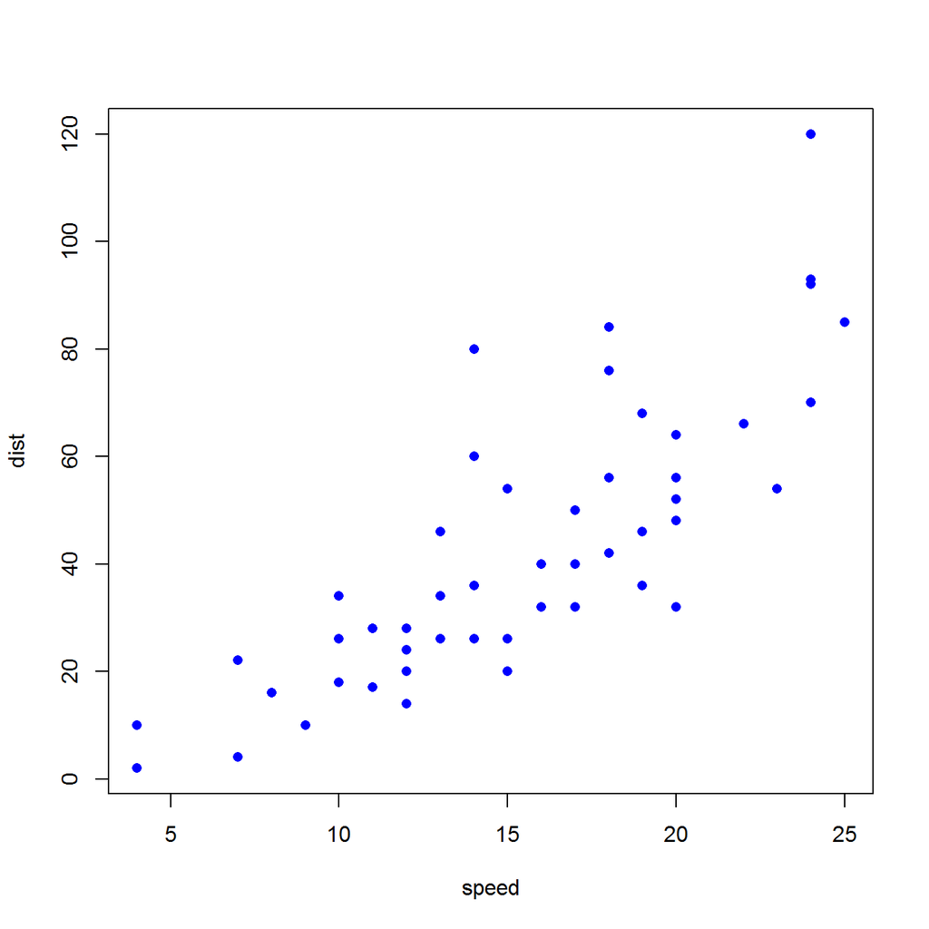

dist versus speed

```r
plot(cars,type="p",xlab="speed",ylab="dist",pch=16,col="blue")
```

# 4 Programando em R

```
if(condição){lista de comandos}
if(condição){lista 1 de comandos} else {lista 2 de comandos}
for(var in seq){lista de comandos}
while(condição){lista de comandos}
repeat{lista de comandos;if(condição){break}}
```

## 4.1 if

```
> x <- 1 # x armazena o valor 1
> p <- runif(1,0,1) # p recebe um número aleatório entre 0 e 1
> p
[1] 0.05151619
> if(p < 1/2){x <- 10}
> x
[1] 10
> x <- 1 # x volta a armazenar o valor 1
> p <- runif(1,0,1) # p recebe um número aleatório entre 0 e 1
> p
[1] 0.8138185
> if(p < 1/2){x <- 10}
> x
[1] 1
```

## 4.2 if/else

```
> x <- 0
> p <- runif(1,0,1) # p recebe um número aleatório entre 0 e 1
> p
[1] 0.2325092
> if(p < 1/3){
+   x <- 10;print("Ganhou 10")
+ } else {
+     x <- -10;print("Perdeu 10")
+ }
[1] "Ganhou 10"
> x
[1] 10
> x <- 0
> p <- runif(1,0,1) # p recebe um número aleatório entre 0 e 1
> p
[1] 0.3470546
> if(p < 1/3){
+   x <- 10;print("Ganhou 10")
+ } else {
+     x <- -10;print("Perdeu 10")
+ }
[1] "Perdeu 10"
> x
[1] -10
```

## 4.3 for

```r
x <- NULL
for(i in 1:10){
  x[i] <- i*9
  print(x)
}
```

```
## [1] 9
## [1]  9 18
## [1]  9 18 27
## [1]  9 18 27 36
## [1]  9 18 27 36 45
## [1]  9 18 27 36 45 54
## [1]  9 18 27 36 45 54 63
## [1]  9 18 27 36 45 54 63 72
## [1]  9 18 27 36 45 54 63 72 81
##  [1]  9 18 27 36 45 54 63 72 81 90
```

```r
x
```

```
##  [1]  9 18 27 36 45 54 63 72 81 90
```

```
> x <- NULL
> for(i in 1:10){
+   x[i] <- i*9
+   print(x)
+ }
[1] 9
[1] 9 18
[1] 9 18 27
[1] 9 18 27 36
[1] 9 18 27 36 45
[1] 9 18 27 36 45 54
[1] 9 18 27 36 45 54 63
[1] 9 18 27 36 45 54 63 72
[1] 9 18 27 36 45 54 63 72 81
[1] 9 18 27 36 45 54 63 72 81 90
```

## 4.4 while

```r
x <- rep(NA,5)
i <- 1
while(i<6){

  x[i] <- i^2
  print(x)
  i <- i+1
}
```

```
## [1]  1 NA NA NA NA
## [1]  1  4 NA NA NA
## [1]  1  4  9 NA NA
## [1]  1  4  9 16 NA
## [1]  1  4  9 16 25
```

```r
x
```

```
## [1]  1  4  9 16 25
```

```
> x <- NA # x possui um valor não disponível (NA: not available)
> is.na(x) # retorna TRUE se x possui um valor NA
[1] TRUE
> i <- 1
> while(i<6){
+   x <- i^2
+   print(x)
+   i <- i+1
+ }
[1] 1
[1] 4
[1] 9
[1] 16
[1] 25
> x
[1] 25
> is.na(x)
[1] FALSE
```

## 4.5 repeat

```
> x <- NA
> is.na(x)
[1] TRUE
> i <- 1
> repeat{
+   x <- i^2
+   print(x)
+   i <- i+1
+   if(i==6){break}
+ }
[1] 1
[1] 4
[1] 9
[1] 16
[1] 25
> x
[1] 25
> is.na(x)
[1] FALSE
```

> UFES - Universidade Federal do Espírito Santo, Centro de Ciências Exatas, Departamento de Estatística. Av. Fernando Ferrari 514, 29075-910, Vitória ES, Brasil.